# 征信系列-用户行为数据分析

DWB

2020/11/20

### $\textbf{·}$ 数据读入

将训练数据集simudata.csv读入：

```r
setwd("E:\\大学\\课程\\专业必修\\大三上\\统计机器学习\\HW\\HW6")
all.data <- read.csv(file="simudata.csv", header=T)
```

### $\textbf{·}$ 箱线图绘制与解读

分别绘制交易笔数-是否违约与用户所有行为金额均值-是否违约箱线图如下所示：

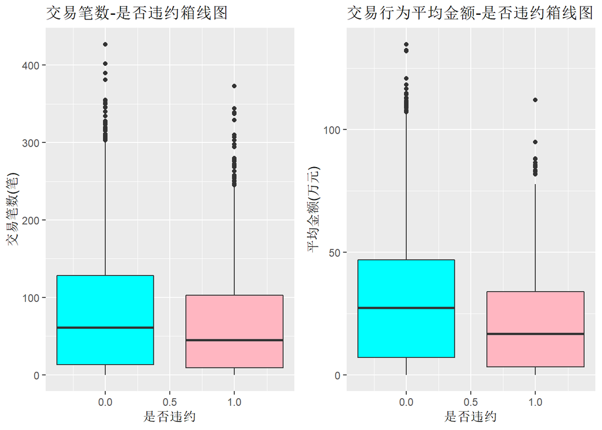

```r
library(ggplot2)
library(grid)
pic1 <- ggplot(all.data, aes(group = black, x = black, y = billnum)) +
  geom_boxplot(fill = c('#00FFFF', '#FFB6C1')) +
  labs(title = "交易笔数-是否违约箱线图", x = "是否违约", y = "交易笔数(笔)")
pic2 <- ggplot(all.data, aes(group = black, x = black, y = meanpay/10000)) +
  geom_boxplot(fill = c('#00FFFF', '#FFB6C1')) +
  labs(title = "交易行为平均金额-是否违约箱线图", x = "是否违约", y = "平均金额(万元)")
grid.newpage()
pushViewport(viewport(layout = grid.layout(1,2)))
vplayout <- function(x,y){
  viewport(layout.pos.row = x, layout.pos.col = y)
}
print(pic1, vp = vplayout(1,1))
print(pic2, vp = vplayout(1,2))
```

从上箱线图可以发现，相比于那些没有违约的用户群体，违约用户群体有着交易笔数较少、交易行为的平均金额较低的特点。

### $\textbf{·}$ 决策树模型的建立与预测

#### $\textbf{·}$ 数据集划分

设置随机数种子为1234，将数据集按照7：3的比例划分为训练集和测试集如下：

```r
set.seed(1234)
sub <- sample(1 : nrow(all.data), round(nrow(all.data) * 0.7))
train.data <- all.data[sub, ]
test.data <- all.data[-sub, ]
```

#### $\textbf{·}$ 模型训练

使用分类决策树模型进行建模，并简要查看其信息如下：

```r
library(rpart)
model <- rpart(black ~ ., data = train.data, method = "class")
printcp(model)
```

```
##
## Classification tree:
## rpart(formula = black ~ ., data = train.data, method = "class")
##
## Variables actually used in tree construction:
## [1] cardnum     creded      debitF      maxpay      meanpay     xindaiR
## [7] zhuanzhangF
##
## Root node error: 1866/5622 = 0.33191
##
## n= 5622
##
##         CP nsplit rel error  xerror     xstd
## 1 0.017149      0   1.00000 1.00000 0.018922
## 2 0.015541      5   0.88639 0.97964 0.018823
## 3 0.010361      6   0.87085 0.95123 0.018677
## 4 0.010000      9   0.83976 0.94695 0.018654
```

可以看到，最终得到的决策树在所有的特征中，仅银行卡数、借贷比率、借记类F（频率）、交易金额最大值、交易金额平均值、信贷类R（最近一次）、转账类F（频率）被使用到，其余特征未被使用。

#### $\textbf{·}$ 测试集上的ROC曲线

使用训练得到的模型对测试集进行预测，并绘制其ROC曲线与AUC值如下：

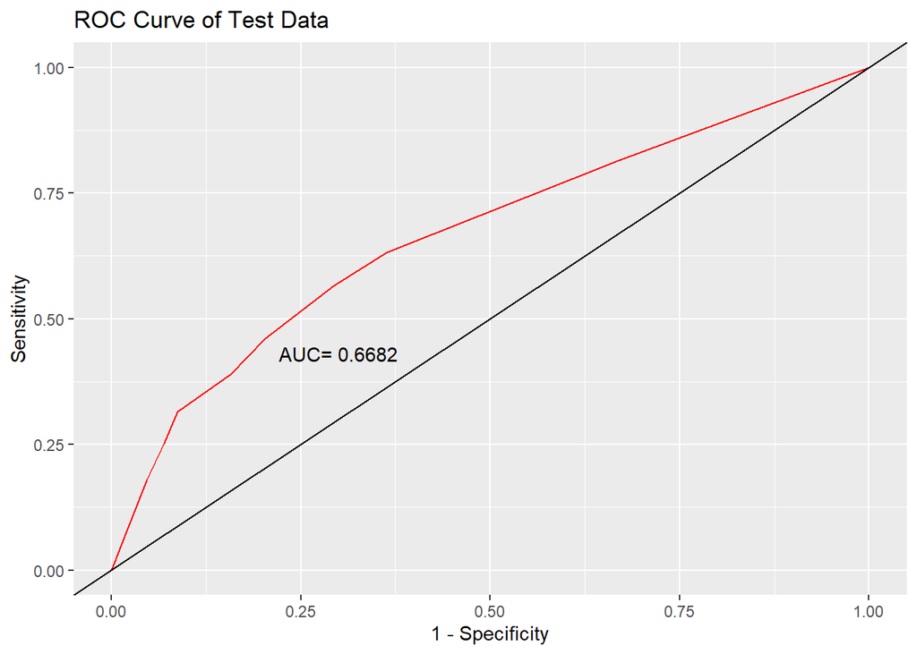

```r
pred <- predict(model, newdata = test.data)
library(pROC)
roc_curve <- roc(test.data$black, pred[ , 2])
x1 <- 1 - roc_curve$specificities
y1 <- roc_curve$sensitivities
ggplot(mapping = aes(x = x1, y = y1)) + geom_line(colour = 'red') + geom_abline(intercept = 0, slope = 1) +
  annotate('text', x = 0.3, y = 0.43, label = paste('AUC=', round(roc_curve$auc,4))) +
  labs(x = '1 - Specificity',y = 'Sensitivity', title = 'ROC Curve of Test Data')
```

看到AUC只有0.6682，预测效果不是特别理想。观察该ROC曲线相比逻辑回归时的AUC曲线平滑，我分析其原因为，决策树会将拥有一些相同特征的数据划分进同一个叶子节点中，这样会有很多数据拥有相同的预测概率值，这样将会导致ROC曲线相对平滑，不那么曲折。

### $\textbf{·}$ 决策树图形与解读

绘制我们的决策树模型如下：

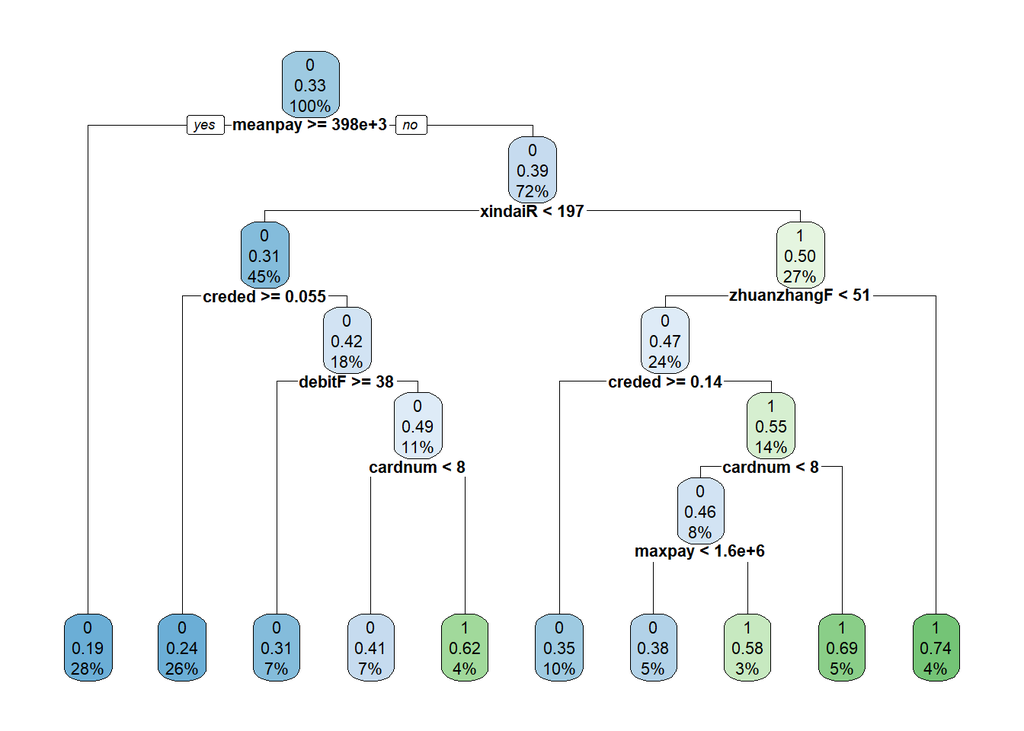

```r
library(rpart.plot)
rpart.plot(model, branch=1, type=2, fallen.leaves=T, cex=0.7)
```

决策树每个节点中有三个信息，最上面的“0”或“1”代表符合该特征的节点将被模型预测为“0”（不会违约）或“1”（会违约）；中间的小数表示概率，代表符合该特征的训练数据中，有多少比例是“1”（会违约），也即表示符合这些特征的数据，最终会违约的经验概率；最后的百分数表示占比，即在该节点上的数据，占训练数据总量的百分比。内部节点也含有这些信息的原因为，这些信息是若将该内部节点下面的节点进行剪枝，该内部节点变为叶子节点后的信息。